# Monthly Giving Per Week Modeling

Sean Davern

June 26, 2019

# Overview

Work to model giving to Seed Church in 2015 noted that giving each month is a function of the number of Sundays that occur in the month on top of varying, somewhat predictably, from month to month. It is also a function of the number of giving families attending Seed Church. This work aims at regressing linear a model of the measure that includes those factors to tools useful for forecasting.
$$\frac{\textit{Monthly Giving}}{n_\textit{Sundays in Month} \cdot n_\textit{Giving Families}}
= a+b_{year}+c_{month}$$

# Load Data

Loading cleaned and transformed (sanitized) giving data originally provided by John Earling:

```r
df <- readRDS("../data/Cleaned and Transformed Giving Data.rds")
df
```

| week.ending | month | year | total | monthly.giving.families | SundaysInMonth | MonthsGivingPerWeek |
| --- | --- | --- | --- | --- | --- | --- |
| 2010-01-31 | January | 2010 | 14241.15 | 45 | 5 | 2848.230 |
| 2010-02-28 | February | 2010 | 22437.50 | 41 | 4 | 5609.375 |
| 2010-03-28 | March | 2010 | 13317.00 | 32 | 4 | 3329.250 |
| 2010-04-25 | April | 2010 | 13232.50 | 36 | 4 | 3308.125 |
| 2010-05-30 | May | 2010 | 13478.15 | 40 | 5 | 2695.630 |
| 2010-06-27 | June | 2010 | 14930.50 | 43 | 4 | 3732.625 |
| 2010-07-25 | July | 2010 | 12824.75 | 36 | 4 | 3206.188 |
| 2010-08-29 | August | 2010 | 15776.00 | 38 | 5 | 3155.200 |
| 2010-09-26 | September | 2010 | 9965.75 | 30 | 4 | 2491.438 |
| 2010-10-31 | October | 2010 | 16112.50 | 40 | 5 | 3222.500 |

[output cut: 91 more lines]

# Adding Columns to Accomodate Analysis

I’ll add a couple columns to enable accommodating for giving anomolies:

```r
suppressMessages(library("dplyr", quietly=TRUE, warn.conflicts = FALSE))
df <- mutate(df,
             removed.amount = 0,
             original.total = total)
```

# Accommodating an Unusually Large Gift

12/26/2016 had an unusual single gift skewing it and analyses. Other large gifts have been recieved over this period but this gift was at least 50% larger than all others. I’m removing the amount of the unusual gift from its month’s total.

```r
df$removed.amount[as.Date(df$week.ending) == "2016-12-25"] <- 20000
df$total <- df$original.total - df$removed.amount
```

# The Measure to be Modeled

The following plot shows the trend of each month’s giving per week per giving family.

```r
df$MonthsGivingPerWeek <- df$total /
                                df$SundaysInMonth /
                                df$monthly.giving.families
```

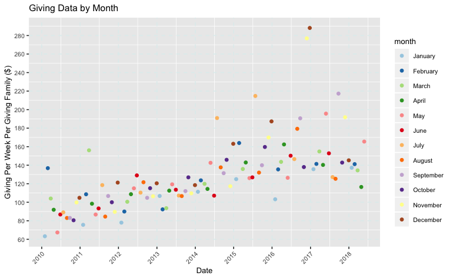

This chart seems to show increasing variation over time especially if the high November and December 2016 data is not anomolous. Following [methods recommended by NIST](https://www.itl.nist.gov/div898/handbook/pmd/section6/pmd633.htm) the following plots allow assessing heteroscedasticity for potential measure transformations (square root, natural log, and inverse (1/x)):

```r
# Create columns of transformed responses:
library("magrittr")
df <- mutate(df, SqrtMonthsGivingPerWeek = sqrt(df$MonthsGivingPerWeek))
df <- mutate(df, logMonthsGivingPerWeek = log(df$MonthsGivingPerWeek))
df <- mutate(df, InvMonthgivingPerWeek = 1/df$MonthsGivingPerWeek)
```

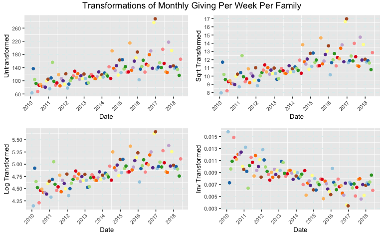

None of the transformations are dramatically better heterscadicity. Of particular question is whether the trend in the measure is mostly linear through the entire period or if it flattens and perhaps even begins to decrease. Keep in mind, this isn’t the total giving, that definitely decreases into 2018. This is whether the average giving per week per family decreases. Such a shift could be a signal of decreased faith in the church or a byproduct of the nature of the giving by the collection of families making up the congregation. Anyway, the end of 2016 high values in all cases seem to be slightly anamolous even though I’ve alread removed the single large gift in December 2016. Despite the similarities in variance consistency, I’m going to move forward with the log transformation because it seem slightly better than untransformed.

# Modeling

Regressing the R version (vs. the JMP approach) of this model:
$$ln{\left[\frac{\textit{Monthly Giving}}
{\textit{Number of Sundays in Month}*\textit{Giving Families}}\right]}
= a+b_{year}+c_{month} + \epsilon$$

where a, $b_{year}$ and $c_{month}$ are regressed model coefficients and $\epsilon$ is error.

```r
mod <- lm( formula = logMonthsGivingPerWeek ~ year + month, data = df)
# Calculate month total giving using regression results:
df <- mutate(df, predicted.values = exp(predict(mod,df))  *
               SundaysInMonth *
               monthly.giving.families) %>%
  mutate(residual.values = total - predicted.values )
```

gives the following model fit assessment:

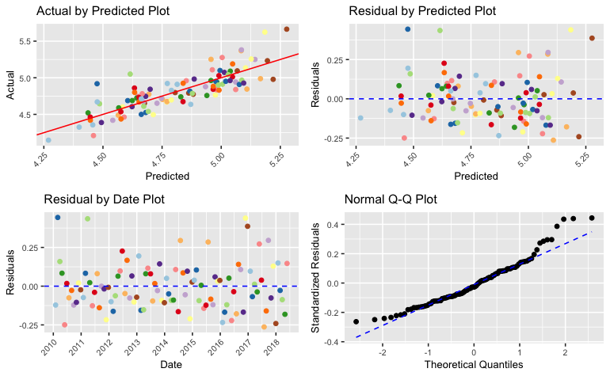

```
Analysis of Variance Table

Response: logMonthsGivingPerWeek
          Df Sum Sq Mean Sq F value    Pr(>F)
year       8 4.1902 0.52377 17.9993 3.748e-15 ***
month     11 0.8925 0.08113  2.7881  0.004002 **
Residuals 81 2.3571 0.02910
---
Signif. codes:  0 ‘***’ 0.001 ‘**’ 0.01 ‘*’ 0.05 ‘.’ 0.1 ‘ ’ 1

Call:
lm(formula = logMonthsGivingPerWeek ~ year + month, data = df)

Residuals:
     Min       1Q   Median       3Q      Max
-0.26331 -0.10444 -0.02756  0.08368  0.44355

Coefficients:
               Estimate Std. Error t value Pr(>|t|)
(Intercept)     4.26972    0.07373  57.911  < 2e-16 ***
year2011        0.12964    0.06964   1.862 0.066292 .
year2012        0.18706    0.06964   2.686 0.008771 **
year2013        0.20607    0.06964   2.959 0.004045 **
year2014        0.39235    0.06964   5.634 2.47e-07 ***
year2015        0.51987    0.06964   7.465 8.43e-11 ***
year2016        0.60149    0.06964   8.637 4.15e-13 ***
year2017        0.54415    0.06964   7.814 1.75e-11 ***
year2018        0.50249    0.09311   5.397 6.59e-07 ***
monthFebruary   0.20535    0.08042   2.554 0.012535 *
monthMarch      0.21589    0.08042   2.685 0.008802 **
monthApril      0.16721    0.08042   2.079 0.040745 *
monthMay        0.19020    0.08042   2.365 0.020411 *
monthJune       0.17646    0.08338   2.116 0.037378 *
monthJuly       0.29491    0.08338   3.537 0.000673 ***
monthAugust     0.17706    0.08338   2.124 0.036751 *
monthSeptember  0.27169    0.08338   3.259 0.001637 **
monthOctober    0.22375    0.08338   2.684 0.008827 **
monthNovember   0.31329    0.08338   3.758 0.000322 ***
monthDecember   0.40589    0.08338   4.868 5.48e-06 ***
---
Signif. codes:  0 ‘***’ 0.001 ‘**’ 0.01 ‘*’ 0.05 ‘.’ 0.1 ‘ ’ 1

Residual standard error: 0.1706 on 81 degrees of freedom
Multiple R-squared:  0.6832,    Adjusted R-squared:  0.6089
F-statistic: 9.193 on 19 and 81 DF,  p-value: 2.571e-13
```

This fit looks reasonably good though the normal quantile plot shows slightly heavy distribution tails. High a low months are not predicted as well. The model clearly differentiates month giving as shown by the significance of the month coefficient terms (see both ANOVA table and coefficients table).

# Model Predictions for Monthly Total Giving

Model results can be used to back calculate the monthly giving totals to observe the fit in that context.

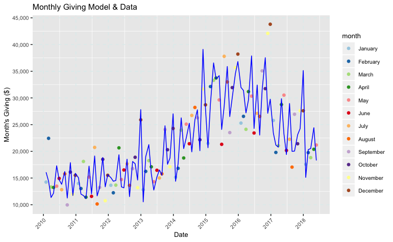

# Model Fit Assessment

Here are the fit assessment graphs with the fit results in the context of the monthly total giving.

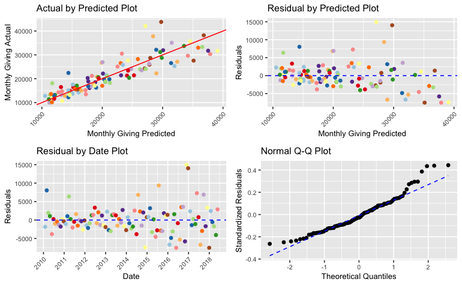

The Residuals by Predicted Plot, in particular, shows the highest giving is over predicted. This could possibly be caused by including a number of other larger donations that might have been one-time donations not representative of “regular” giving. However, those obviously happen occassionally so including them causes the model to predict presuming they will happen.

The overall model root mean square error (RSME) in the modeled monthly giving is:

```
[1] $ 3,798.87
```

This value is helpful in establishing an income variability fund to offset giving variation. The RSME is a good, non-biased estimator of the standard deviation ($\sigma$) of the distribution of residuals. The normal quantile plot above shows the majority of the residual distribution are normally distributed. While the tails (residuals at the high and low end of giving) are more common than a normal distribution, the high giving is more common than the lows.

# Modeling Monthly Variation

An useful aspect of the model chosen is that it can be rearranged in a useful way for forecasting. The following discussion shows that rearrangement. Starting with the model for the natural log transformed giving per Sunday per month per giving family:

$$\begin{aligned}
\begin{split}
ln{\left[\frac{\textit{Monthly Giving}}{n_\textit{Sundays in Month} \cdot n_\textit{Giving Families}}\right]}
&= a+b_{year}+c_{month}
\\
\\
\frac{\textit{Monthly Giving}}{n_\textit{Sundays in Month}\cdot n_\textit{Giving Families}}
&= e^{(a+b_{year}+c_{month})}
\end{split}
\end{aligned}$$
Shifting the $b_{year}$ and $c_{month}$ coefficients as previously discussed in the “Transfer of 2013 Analysis” notebook gives:
$$\begin{aligned}
\begin{split}
\frac{\textit{Monthly Giving}}{n_\textit{Sundays in Month}*n_\textit{Giving Families}}
&= e^{
\left(
\big[a+\overline{b_{year}} + \overline{c_{month}}\big]+
(b_{year}-\overline{b_{year}})+
(c_{month}-\overline{c_{month}})
\right)}
\\
&= e^{
\left(
\big[a+\overline{b_{year}}+\overline{c_{month}}\big]+
b^\prime_{year} + c^\prime_{month}
\right)}
\\
&= e^{\left(a+\overline{b_{year}}+\overline{c_{month}}\right)} \cdot
e^{(b^\prime_{year})} \cdot e^{(c^\prime_{month})}
\end{split}
\end{aligned}$$
The $e^{\left(a+\overline{b_{year}}+\overline{c_{month}}\right)} \cdot e^{(b^\prime_{year})}$ collection of terms is the average giving per Sunday per month per family in any particular year of interest. When $b^\prime_{year}=0$ and $c^\prime_{month}=0$ the $e^0$ terms are 1 and the model returns that **average** month. The $e^{c^\prime_{month}}$ terms are multipliers that provide a specific month’s estimate for a given (or average) year. These are the values of the $e^{c^\prime_{month}}$ terms:

```r
mon.coef <- c(0, mod$coefficients[10:20])
names(mon.coef) <- month.name
mon.coef <- exp(mon.coef - mean(mon.coef))
mon.coef
```

```
  January  February     March     April       May      June      July    August September   October  November  December
0.8024041 0.9853194 0.9957573 0.9484475 0.9704993 0.9572571 1.0776346 0.9578336 1.0529001 1.0036176 1.0976215 1.2041195
```

Notice the average of the monthly coeffiecients is very close to 1:

```r
mean(mon.coef)
```

```
[1] 1.004451
```

I’ll reorder the vector of these coefficients to concide with the order of the fiscal year rather than the calendar year. The values are not changed just the order.

```r
monthsInFYOrder <- c(month.name, month.name)[7:18]
mon.coef <- mon.coef[monthsInFYOrder]
mon.coef
```

```
     July    August September   October  November  December   January  February     March     April       May      June
1.0776346 0.9578336 1.0529001 1.0036176 1.0976215 1.2041195 0.8024041 0.9853194 0.9957573 0.9484475 0.9704993 0.9572571
```

The $e^{\left(a+\overline{b_{year}}+\overline{c_{month}}\right)} \cdot e^{(b^\prime_{year})}$ quantity can also be determined from annual data:
$$e^{\left(a+\overline{b_{year}}+\overline{c_{month}}\right)} \cdot
e^{(b^\prime_{year})} = \frac{Giving_{year}}{n_{\textit{Sundays in Yr}}
\cdot \overline{n}_f}$$
Where $\overline{n}_f$ is the average number of families giving over the year.
Shortening the model expression with $n_\textit{Sundays in Month}=n_S$ and $n_\textit{Giving Families}=n_F$, both monthly values, and moving them over to the right we get:

$$\textit{Monthly Giving} =
n_S*n_F \cdot e^{\left(a+\overline{b_{year}}+\overline{c_{month}}\right)}
\cdot e^{(b^\prime_{year})} \cdot e^{c^\prime_{month}}$$
Summing both sides over some range of months:
$$\begin{aligned}
\begin{split}
\sum_{Months}\textit{Monthly Giving} = Giving_{Total} &=
\sum_{Months}{ \left[
n_S*n_F \cdot e^{\left(a+\overline{b_{year}}+\overline{c_{month}}\right)}
\cdot e^{(b^\prime_{year})} \cdot e^{c^\prime_{month}}
\right]}
\\
&= e^{\left(a+\overline{b_{year}}+\overline{c_{month}}\right)}
\cdot e^{(b^\prime_{year})} \cdot \sum_{Months}{ \left[
n_S*n_F \cdot e^{c^\prime_{month}}
\right]}
\end{split}
\end{aligned}$$
substituting for the $e^{\left(a+\overline{b_{year}}+\overline{c_{month}}\right)} \cdot e^{(b^\prime_{year})}$ terms gives:
$$\begin{aligned}
\begin{split}
Giving_{Total} &=
\frac{Giving_{year}}{n_{\textit{Sundays in Yr}}
\cdot \overline{n}_f}
\cdot \sum_{Months}{ \left[
n_S*n_F \cdot e^{c^\prime_{month}} \right]}
\\
&=
\frac{Giving_{year}}{\overline{n}_f}
\cdot \sum_{Months}{ \left[ \left(
\frac{n_S}{n_{\textit{Sundays in Yr}}} \right)
\cdot e^{c^\prime_{month}} *n_F \right]}
\end{split}
\end{aligned}$$
Then, if $n_F$, the number of giving families in each month, is taken to be a constant average number, $\overline{n}_f$ that term can be pulled out of the sum and cancels.
$$\begin{aligned}
\begin{split}
Giving_{Total} &=
Giving_{year}
\cdot \sum_{Months}{ \left[ \left(
\frac{n_S}{n_{\textit{Sundays in Yr}}} \right)
\cdot e^{c^\prime_{month}} \right]}
\end{split}
\end{aligned}$$
It is this collection of terms inside the sum that provides the number-of-Sundays-in-each-month correction to the $e^{c^\prime_{month}}$ coefficients regressed in the model.
The following function calculates the vector of $n_S/n_{\textit{Sundays in Yr}}$ and shows the result for 2019:

```r
Sunday.Corrections <- function(year) {
# This function get a list of the Sundays in the fiscal year from July 1, year to June 30, year+1
  getSundaysInFY <- function(yr) {
    startDate <- paste0(yr,"-07-01")
    endDate <- paste0(yr+1,"-06-30")
    dates <- seq(as.Date(startDate),as.Date(endDate), by = "day")
    dates[weekdays(dates) == "Sunday"]
  }
  SundaysInYr <- getSundaysInFY(year)  # List of dates of Sundays in the year
  numSundaysInFY <- length(SundaysInYr) # Number of Sundays in the year: 52 or 53
  x <- strftime(SundaysInYr,"%m")  # Month listed once for each Sunday it contains
  numSundaysInMonths <- table(factor(x,unique(x), ordered = TRUE))  # Sundays in each month.
  names(numSundaysInMonths) <- c(month.name,month.name)[7:18]  # Convert names to month Names
  Corrections <- numSundaysInMonths / numSundaysInFY
  Corrections
}
Sunday.Corrections(2019)
```

```
      July     August  September    October   November   December    January   February      March      April
0.07692308 0.07692308 0.09615385 0.07692308 0.07692308 0.09615385 0.07692308 0.07692308 0.09615385 0.07692308
       May       June
0.09615385 0.07692308
```

If each month had $52/12 = 4\frac{1}{3}$ Sundays and there were 52 Sundays in the year, this vector would be all 0.083333. Instead both the monthly and annual number of Sundays vary leading to the modeled income variation.

# Making Projections

We can now calculate the vector of $(n_S/n_{\textit{Sundays in Yr}}) \cdot e^{c^\prime_{month}}$ products for the fiscal year beginning in July, 2019:

```r
Giving.Fractions <- Sunday.Corrections(2019)*mon.coef
Giving.Fractions
```

```
      July     August  September    October   November   December    January   February      March      April
0.08289497 0.07367951 0.10124039 0.07720135 0.08443242 0.11578072 0.06172339 0.07579380 0.09574589 0.07295750
       May       June
0.09331724 0.07363516
```

Notice this vector sums to nearly 1, but given the inputs (model regressions and a fiscal year’s distribution of Sundays) it is not exactly 1.

```r
sum(Giving.Fractions)
```

```
[1] 1.008402
```

To keep the months so they sum exactly to the total we can normalize them:

```r
Giving.Fractions <- Giving.Fractions / sum(Giving.Fractions)
Giving.Fractions
```

```
      July     August  September    October   November   December    January   February      March      April
0.08220426 0.07306559 0.10039682 0.07655809 0.08372890 0.11481599 0.06120909 0.07516226 0.09494811 0.07234959
       May       June
0.09253969 0.07302161
```

```r
cat("Sum = ", sum(Giving.Fractions))
```

```
Sum =  1
```

Finally, a plot showing the relative magnitudes of the predicted monthly giving for the fiscal year beginning in July, 2019.

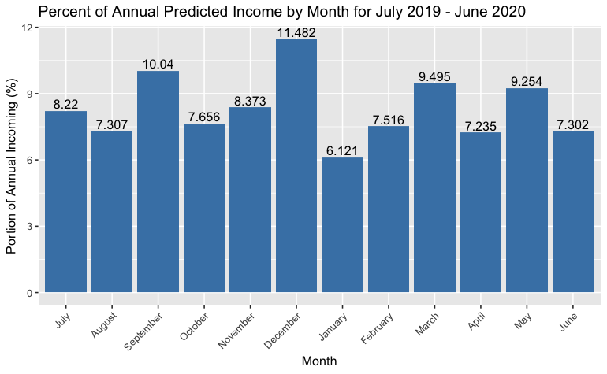

This projection assumes that 1) giving follows patterns true between 2010 and 2018, that 2) the number of giving families is constant over the projection period and 3) the giving families giving practices are stable.

Another potential use of the modeling result is to use the January through June income from the preceeding fiscal year to project the following fiscal year. A sum of the January through June portions gives:

```r
previous.year <- Sunday.Corrections(2018)*mon.coef
previous.year <- previous.year / sum(previous.year)
previous.year[7:12]
```

```
   January   February      March      April        May       June
0.05999136 0.07366693 0.09305914 0.07091022 0.07255891 0.08946108
```

```r
cat("Sum = ", sum(previous.year[7:12]))
```

```
Sum =  0.4596476
```

So, an estimate of FY2019 giving is:
$$\textit{FY2019 Giving}= \frac {
\sum_{Jan-Jun}{(\textit{2019 Giving})}
}{0.46}\cdot
\frac{\overline{n}_\textit{Giving Families in FY2019}}{\overline{n}_\textit{Giving Families in Jan-Jun 2019}}$$
where $\overline{n}\text{'s}$ are the average number for the period indicated by subscripts.

Again, this assumes giving follows historic patterns and giving per family is the same as in Jan-Jun 2019.

Note: this prediction would be impacted by giving anomolies that impact the $\textit{2019 Giving}$ quantity like a significant amount of missing checks if they didn’t make it in my the end of June.

# Modeling Criticism

One of the issues this modeling approach has is that regression assumes that factors are not correlated. For example, giving one month does not affect giving the next month. This is almost certainly not perfectly true. For example, the model shows a repeated December to January drop in giving. It could be that givers sometimes choose to move up a gift they planned to make in January to December for tax benefits. Thus, it might be common that high giving one month could lead to lower giving the next month. This leads to a statistical correlation between the year term estimates. Separate from those examples, a regular giver’s giving one month is highly likely to predict their giving the next month, similarly for the collection of regular givers’. On the one hand, that predictability is what the model is attempting to capture. On the other hand, it also provides the correlation between factors. For example, a regular giver’s donation that occurs bi-weekly could land within consecutive months based on paydays. Regular givers that are paid and donate monthly are less likely to have the same “correlation”. For this reason, regression is perhaps not as technically appropriate as time series analysis. Perhaps this just adds to George Box’s point that all models are wrong, some are useful.